# Quantitative Research

Optimization Problem of Portfolio

# 1 Prepare data

## 1.1 Get data

1. You have flexibility to choose the source for downloading stock price. One option would be yahoo finance: https://help.yahoo.com/kb/SLN2311.html

```r
GetMySymbols <- function(x) {getSymbols(x,
                                 src = 'yahoo',
                                 from = '2017-12-30',
                                 to = '2023-12-30',
                                 auto.assign = FALSE)
}
tickers <- c("AAPL", "ABBV", "ABT", "ACN", "ADBE", "AIG", "AMGN", "AMZN", "AVGO", "BA", "BABA", "BAC", "BDX", "BIIB", "BK", "BMY", "C", "CAT", "IOACU", "CHTR", "CL", "CMCSA", "CME", "COP", "COST", "CRM", "CSCO", "CVS", "CVX", "DD", "DIS", "DOW", "DUK", "EMR", "EXC", "F", "IOAC", "FDX", "FOX", "FOXA", "GD", "GE", "GILD", "GM", "GOOGL", "GS", "HAL", "HD", "HON", "IBM", "INTC", "INTU", "ISRG", "JNJ", "JPM", "KHC", "KMI", "KO", "LLY", "LMT", "LOW", "MA", "MCD", "MDLZ", "MDT", "MET", "MMM", "MO", "SDIG", "MRK", "MS", "MSFT", "NEE", "NFLX", "NKE", "NVDA", "ORCL", "OXY", "PEP", "PFE", "PG", "PM", "PYPL", "QCOM", "RTX", "SBUX", "SLB", "SO", "SPG", "T", "TGT", "TMO", "TSLA", "TXN", "UNH", "UNP", "UPS", "USB", "V", "VZ")
```

## 1.2 Save into a price matrix

2. Download historical stock price of 100 stocks with at least 5 year historical data and save it into a price matrix of $m \times n$ ($m$: number of days, $n$: number of stocks (100)):

```r
price_matrix <- map(tickers, GetMySymbols)
```

3. Derive return matrix R from the above price matrix:

Using Log Return: $R_t = \ln \bigg(\frac{P_t}{P_{t-1}}\bigg) = \ln(P_t) - \ln(P_{t-1})$

```r
prices_adjusted <- price_matrix %>% map(Ad) %>% reduce(merge.xts)
names(prices_adjusted) <-tickers
returns <- Return.calculate(prices_adjusted, method = "log") %>% na.omit()
returns <- as.matrix(returns)
```

# 2 Solve the problem of optimization

**Question:** Find an optimal money allocation ($w_1, w_2, w_3 …, w_{100}$) so that for a given risk level we achieve maximum return with below constraints:

$$w_i ≥ 0 \text{ for all } i = 1,2,3,...,100. \\ |w_1 + w_2 + … + w_{100}| = 1.$$

## 2.1 Method 1: Using the inequality-constrained optimization method.

To find an optimal money allocation, I apply the inequality-constrained optimization method to solve our problem.

### 2.1.1 Formulate the problem

The standard deviation of the portfolio return is consider as a measure the risk of the portfolio. Since, it measures the variability of the portfolio return around its expected value.

Portfolios with **higher returns often require higher risks** and higher risks may not have higher returns.

The variance of a portfolio return can be reduced by including additional assets in the portfolio, a process referred to as diversification.

With a given desired return, I want to build a portfolio with lowest risks.

Consider a portfolio with 100 stocks. Let $w_1, w_2, w_3, ..., w_{100}$ are the weights and $r_1, r_2, r_3, ..., r_{100}$ are the annual mean return of $S_1,S_2,S_3,..., S_{100}$ in the portfolio. The expected rate of return $r$ of the portfolio is

$$r= E(r) = w_1 r_1+ w_2 r_2 + w_3 r_3 + ... + w_2 r_{100}.$$

**Remark:** The problem is that find an optimal money allocation ($w_1, w_2, w_3 …, w_{100}$) so that for a given risk level, we achieve maximum return. However, maybe we can think that find an optimal money allocation ($w_1, w_2, w_3 …, w_{100}$) so that for a given return, we achieve minimum risk level. Therefore, we need to solve the optimization problem:

Minimize: $\sigma^2$

Subject to: $w_1+w_2+w_3+...+ w_{100} = 1, w_1 r_1+w_2 r_2+w_3 r_3+...+ w_{100} r_{100} = r. \\ w_1 \geq 0, w_2 \geq 0, w_3 \geq 0,..., w_{100} \geq 0.$

Let $D$ be the covariance matrix:
$$D=\begin{bmatrix}
\sigma^2_1 & \rho_{12}\sigma_1\sigma_2 & \rho_{13}\sigma_1\sigma_3 & \ldots & \rho_{1100}\sigma_1\sigma_{100}\\
\rho_{21}\sigma_2\sigma_1 & \sigma^2_2 & \rho_{23}\sigma_2\sigma_3 & \ldots & \rho_{2100}\sigma_2\sigma_{100}\\
\rho_{31}\sigma_3\sigma_1 & \rho_{32}\sigma_3\sigma_2 & \sigma^2_3 & \ldots & \rho_{3100}\sigma_3\sigma_{100}\\
\vdots &\vdots &\vdots &\vdots &\vdots\\
\rho_{1001}\sigma_{100}\sigma_1 & \rho_{1002}\sigma_{100}\sigma_2 & \rho_{1003}\sigma_{100}\sigma_3 & \ldots & \sigma^2_{100} \\
\end{bmatrix}$$
, and
$$w= \begin{bmatrix} w_1 \\ w_2 \\ w_3 \\ \vdots \\ w_{100} \end{bmatrix}$$
be the weights of $S_1,S_2,S_3,..., S_{100}$

The objective function can be represented:

$$\sigma^2 = w^T*D*w =\frac{1}{2} w^T*(2D)*w$$

Let
$$A = \begin{bmatrix}
1 & r_1 & 1 & 0 & 0 & \ldots & 0\\
1 & r_2 & 0 & 1 & 0 & \ldots & 0\\
1 & r_3 & 0 & 0 & 1 & \ldots & 0\\
\vdots &\vdots &\vdots &\vdots &\vdots &\vdots &\vdots\\
1 & r_{100} & 0 & 0 & 0 & \ldots & 1\\
\end{bmatrix}$$
,
$$b_0 = \begin{bmatrix} 1 \\ r \\ 0 \\ \vdots \\ 0 \end{bmatrix}$$
and
$$d = \begin{bmatrix} 0 \\ 0 \\ 0 \\ \vdots \\ 0 \end{bmatrix}$$
.

The constraints can be written as:
$$\begin{equation}
\begin{cases}
w_1+w_2+w_3+...+ w_{100} &=& 1\\
w_1 r_1+w_2 r_2+w_3 r_3+...+ w_{100} r_{100} &=& r\\
w_1 &\geq& 0 \\
w_2 &\geq& 0 \\
w_3 &\geq& 0 \\
\vdots \\
w_{100} &\geq& 0
\end{cases}
\iff \begin{bmatrix}
1 & 1 & 1 & \ldots & 1\\
r_1 & r_2 & r_3 & \ldots & r_{100}\\
1 & 0 & 0 & \ldots & 0\\
0 & 1 & 0 & \ldots & 0\\
0 & 0 & 1 & \ldots & 0\\
\vdots &\vdots &\vdots &\vdots &\vdots\\
0 & 0 & 0 & \ldots & 1 \\
\end{bmatrix}\begin{bmatrix}
w_1\\
w_2\\
w_3\\
\vdots\\
w_{100}\\
\end{bmatrix} \geq \begin{bmatrix}
1\\
r\\
0\\
0\\
0\\
\vdots\\
0\\
\end{bmatrix} \iff A^Tb \geq b_0
\end{equation}$$

The problem now can be expressed as a Quadratic Programming Problem of the form min$(−d^Tb+\frac{1}{2}b^TDb)$ with the constraints $A^Tb \geq b_0$, with above notation.

### 2.1.2 Case 1: A given desired return

With a given desired return 0.0886, I want to build a portfolio with lowest risks.

Geometric Mean Return $= \bigg[(1+r_{(1)})(1+r_{(2)})(1+r_{(3)})...(1+r_{(d)})\bigg]^{\frac{1}{d}}-1$

Where, $r$: rate of return and $d$: number of periods

```r
annual_mean_return <- matrix(Return.annualized(returns, scale = 252, geometric = TRUE),1,100)
```

```r
Dmat <- cov(returns)
dvec  <- c(matrix(0, nrow = 100, ncol = 1))
Amat <- t(rbind(rep(1, ncol(annual_mean_return)), annual_mean_return, + diag(1, nrow = ncol(annual_mean_return))))
b0       <- c(1,0.0886,rep(0,100))
n.eqs      <- 2 # Constraints are equalities
sol <- solve.QP(2*Dmat,dvec,Amat,bvec=b0,meq=n.eqs)
```

```r
# Give the weights in the lowest risk
efficient_variance_port <- sol$solution
efficient_variance_port
```

```
##   [1]  8.002873e-17  5.213244e-02 -6.696522e-17  6.271105e-17  2.308121e-17
##   [6]  1.405784e-16  5.710112e-02 -6.171770e-18  3.504370e-18 -7.150753e-18
##  [11]  2.647590e-03 -1.781751e-16 -1.020999e-16  2.107266e-17  3.094827e-17
##  [16] -1.634889e-18 -9.291425e-18  2.034190e-18  5.435938e-02  6.152563e-18
##  [21]  1.007585e-02 -2.854954e-17  8.558602e-02 -6.819847e-17  2.298745e-17
##  [26] -4.815993e-18  4.337886e-17  1.644686e-18  4.114017e-02  5.422660e-17
##  [31]  1.064092e-17  1.485768e-17  8.381799e-17  7.101884e-17  5.701210e-17
##  [36]  6.861987e-18  6.355847e-02  5.746872e-03  3.230857e-17 -4.533631e-20
##  [41] -8.640897e-17  1.949877e-02 -6.098002e-17 -8.625904e-18  8.692657e-19
##  [46]  3.365374e-18 -3.552793e-17 -1.108391e-17 -1.184153e-17  1.016303e-01
##  [51] -6.639173e-18  3.933395e-17  4.066612e-17  0.000000e+00  9.412037e-19
##  [56]  4.098088e-02  5.033560e-17  1.511860e-17  4.879337e-02  1.052615e-01
##  [61]  3.389771e-18 -5.472675e-17  1.054479e-01  8.993506e-03 -1.897458e-17
##  [66]  2.654782e-17  1.525326e-17  1.502190e-02  6.215125e-20  1.498820e-01
##  [71] -3.239530e-17  8.389077e-19 -3.041589e-17  3.804739e-18  7.465112e-17
##  [76]  5.006892e-18  4.591479e-03  8.919299e-19 -3.211936e-16 -2.537082e-18
##  [81]  9.971681e-17  9.907079e-04  2.510764e-18  2.257880e-18  3.360646e-17
##  [86] -5.456743e-17 -7.977329e-18  6.099757e-17 -2.795566e-17 -1.132442e-17
##  [91] -8.440917e-17  3.849971e-17 -1.569492e-18 -2.624541e-17  8.278824e-17
##  [96] -3.389501e-18 -1.482891e-17 -2.292008e-17 -1.084026e-17  2.655971e-02
```

```r
# Give the portfolio's volatility
sqrt(sol$value)
```

```
## [1] 0.007320322
```

Therefore, we obtain the desired efficient variance portfolio has $w_1, w_2, w_3, ..., w_{100}$ (results above) with the corresponding volatility 0.007320323 that is the lowest risk in a give return of 0.0886.

### 2.1.3 Case 2: A range of return values

I want to check how each return value will produce a weight matrix that makes the risk the lowest, instead of just using one input return value. And these return numbers will run from the lowest annual mean return to the highest of a stock, specifically in increments of 100.

```r
# Construct the Target Portfolio Return Vector
avg.ret=c(annual_mean_return)
min.ret<-min(avg.ret)
max.ret<-max(avg.ret)
increments=100
tgt.ret<-seq(min.ret,max.ret,length=increments)
head(tgt.ret)
```

```
## [1] -0.8873776 -0.8739293 -0.8604809 -0.8470326 -0.8335843 -0.8201359
```

```r
# Construct Dummy Portfolio Weights Vector
wgt<-matrix(0,nrow=increments,ncol=length(avg.ret))
# Construct Dummy Portfolio Standard Deviation Vector
tgt.sd<-rep(0,length=increments)
```

```r
# Run the quadprog Optimizer
Dmat <- 2*cov(returns)
Dmat <- as.matrix(nearPD(Dmat)$mat)
dvec <- c(rep(0,length(avg.ret)))
Amat <- cbind(rep(1,length(avg.ret)),avg.ret, + diag(1,nrow=ncol(Dmat)))

for (i in 2:(increments-1)){
  bvec <- c(1,tgt.ret[i],rep(0,ncol(Dmat)))
  soln <- solve.QP(Dmat,dvec,Amat,bvec=bvec,meq=2)
  tgt.sd[i] <- sqrt(soln$value)
  wgt[i,] <- soln$solution}
head(tgt.sd)
```

```
## [1] 0.00000000 0.07933767 0.07694512 0.07456748 0.07220622 0.06986299
```

This result shows the lowest standard deviation of each return level.

```r
# Printed results: the main column is the stock, and the main row is each return value at i. Each row representing each return will have its own weight
tail(data.frame(wgt))
```

```
##                X1            X2            X3           X4            X5
## 95   2.173059e-16  4.106743e-17 -2.058473e-16 3.465943e-17  1.186918e-17
## 96   1.764696e-16 -4.387922e-17 -2.196249e-16 5.848695e-17  1.449530e-17
## 97  -6.051730e-16  1.923595e-16 -2.200564e-16 4.028480e-17 -1.226680e-17
## 98  -5.699221e-17  9.272875e-17 -2.557343e-16 3.037716e-17 -1.498704e-16
## 99  -6.529156e-17  1.074656e-16 -2.775343e-16 2.046952e-17 -1.403915e-16
## 100  0.000000e+00  0.000000e+00  0.000000e+00 0.000000e+00  0.000000e+00
##                X6            X7            X8         X9           X10
## 95   2.338237e-17 -8.260211e-18 -4.214592e-17 0.07248215  3.408670e-17
## 96  -1.978843e-16 -1.038899e-17 -1.853057e-17 0.06961962  9.261018e-17
## 97  -1.722688e-16 -6.322867e-18 -7.118489e-17 0.06602968  6.825096e-17
## 98  -2.499380e-17  7.123422e-17 -2.676246e-17 0.05219211 -9.766159e-19
## 99  -4.797380e-17 -4.844930e-18 -2.765832e-17 0.03835454 -4.864050e-17
## 100  0.000000e+00  0.000000e+00  0.000000e+00 0.00000000  0.000000e+00
##               X11          X12           X13           X14           X15
```

[output cut: 125 more lines]

This result shows that in each return we will obtain a matrix weight to minimize the risk.

```r
colnames(wgt)<-paste0("wgt.S",1:100)
```

```r
# Combine Portfolio Returns, Portfolio Standard Deviations, and Portfolio Weights
tgt.port<-(data.frame(cbind(tgt.ret,tgt.sd,wgt)))[c(-1,-100), ]
tail(tgt.port)
```

```
##      tgt.ret     tgt.sd        wgt.S1        wgt.S2        wgt.S3        wgt.S4
## 94 0.3633183 0.01334291  1.861979e-16  6.212835e-17 -4.799112e-17 -1.815925e-16
## 95 0.3767667 0.01391068  2.173059e-16  4.106743e-17 -2.058473e-16  3.465943e-17
## 96 0.3902150 0.01450943  1.764696e-16 -4.387922e-17 -2.196249e-16  5.848695e-17
## 97 0.4036634 0.01513569 -6.051730e-16  1.923595e-16 -2.200564e-16  4.028480e-17
## 98 0.4171117 0.01582479 -5.699221e-17  9.272875e-17 -2.557343e-16  3.037716e-17
## 99 0.4305601 0.01659743 -6.529156e-17  1.074656e-16 -2.775343e-16  2.046952e-17
##           wgt.S5        wgt.S6        wgt.S7        wgt.S8     wgt.S9
## 94 -3.914430e-17 -7.730523e-18  9.217581e-18 -8.802144e-17 0.07538455
## 95  1.186918e-17  2.338237e-17 -8.260211e-18 -4.214592e-17 0.07248215
## 96  1.449530e-17 -1.978843e-16 -1.038899e-17 -1.853057e-17 0.06961962
## 97 -1.226680e-17 -1.722688e-16 -6.322867e-18 -7.118489e-17 0.06602968
## 98 -1.498704e-16 -2.499380e-17  7.123422e-17 -2.676246e-17 0.05219211
## 99 -1.403915e-16 -4.797380e-17 -4.844930e-18 -2.765832e-17 0.03835454
##          wgt.S10       wgt.S11      wgt.S12       wgt.S13       wgt.S14
```

[output cut: 132 more lines]

However, there are two options to choose the efficient portfolio that is the minimum variance and the maximum Sharpe ratio.

#### 2.1.3.1 Option 1: Choosing the efficient portfolio having the minimum variance

```r
# Identify the Minimum Variance Portfolio
minvar.port<-subset(tgt.port,tgt.port$tgt.sd==min(tgt.port$tgt.sd))
minvar.port
```

```
##         tgt.ret      tgt.sd       wgt.S1     wgt.S2       wgt.S3       wgt.S4
## 67 0.0002130625 0.007021115 2.545289e-17 0.04309301 6.683105e-17 8.093105e-17
##          wgt.S5       wgt.S6     wgt.S7        wgt.S8       wgt.S9      wgt.S10
## 67 1.250175e-17 1.270257e-17 0.01220971 -1.446897e-17 1.719748e-17 5.976492e-18
##       wgt.S11       wgt.S12      wgt.S13      wgt.S14      wgt.S15    wgt.S16
## 67 0.01402681 -1.170365e-16 4.687234e-17 -1.93448e-18 -2.97254e-17 0.06607151
##          wgt.S17      wgt.S18    wgt.S19      wgt.S20    wgt.S21       wgt.S22
## 67 -1.777791e-17 5.579007e-18 0.05529323 6.910741e-18 0.05140234 -3.866539e-19
##      wgt.S23      wgt.S24      wgt.S25      wgt.S26      wgt.S27      wgt.S28
## 67 0.0875737 3.398885e-17 7.475363e-17 1.058977e-18 3.138021e-17 8.172177e-18
##       wgt.S29       wgt.S30      wgt.S31      wgt.S32       wgt.S33
## 67 0.03118115 -3.235281e-17 3.261071e-18 6.254477e-18 -9.252295e-17
##          wgt.S34     wgt.S35      wgt.S36    wgt.S37     wgt.S38       wgt.S39
## 67 -2.012344e-17 4.67456e-19 6.692394e-17 0.07241773 0.006260485 -4.686225e-17
##       wgt.S40     wgt.S41       wgt.S42       wgt.S43      wgt.S44      wgt.S45
## 67 0.02306069 2.50233e-17 -1.801717e-17 -1.018461e-17 1.377107e-17 2.367606e-17
##         wgt.S46       wgt.S47     wgt.S48      wgt.S49   wgt.S50      wgt.S51
## 67 4.070955e-17 -3.875677e-17 1.88875e-17 5.781011e-18 0.0463816 2.928549e-17
##         wgt.S52      wgt.S53    wgt.S54      wgt.S55    wgt.S56       wgt.S57
## 67 1.295192e-18 2.163684e-17 0.09982489 4.705467e-17 0.04586694 -7.414608e-17
##          wgt.S58       wgt.S59   wgt.S60      wgt.S61       wgt.S62    wgt.S63
## 67 -1.312695e-17 -9.152817e-18 0.0853205 4.544105e-18 -1.419924e-17 0.09524042
##         wgt.S64      wgt.S65       wgt.S66      wgt.S67    wgt.S68
## 67 5.092415e-17 3.230139e-18 -5.758753e-17 -2.95118e-17 0.02882164
##          wgt.S69    wgt.S70       wgt.S71       wgt.S72       wgt.S73
## 67 -5.034549e-19 0.05192016 -8.396071e-17 -1.555048e-19 -1.024453e-17
##         wgt.S74      wgt.S75      wgt.S76     wgt.S77       wgt.S78
## 67 1.350815e-18 6.483986e-17 1.213688e-18 0.009116753 -2.035635e-18
##         wgt.S79       wgt.S80      wgt.S81      wgt.S82       wgt.S83
## 67 1.756537e-16 -1.801676e-18 5.014061e-17 3.615828e-17 -1.109859e-17
##         wgt.S84       wgt.S85       wgt.S86       wgt.S87      wgt.S88
## 67 9.370036e-18 -2.864332e-18 -2.037105e-17 -3.790886e-18 1.603572e-17
##         wgt.S89       wgt.S90       wgt.S91      wgt.S92       wgt.S93
## 67 2.217499e-17 -2.378131e-18 -8.582596e-17 7.081474e-18 -5.456645e-21
##         wgt.S94      wgt.S95       wgt.S96      wgt.S97      wgt.S98
## 67 1.629205e-18 1.649925e-18 -4.554863e-18 4.939265e-18 4.869558e-17
##         wgt.S99   wgt.S100
## 67 2.184345e-17 0.07491673
```

From this, we can choose 0.007021118 that is the lowest standard deviation. And it has own weight vector for the portfolio.

```r
par(mfrow=c(10,10))
weight_minvar <- minvar.port[, paste0("wgt.S", 1:100), drop = FALSE]
colnames(weight_minvar) <-paste(tickers)
weight_minvar <- weight_minvar[1, ]
# Normalize weights to sum to 1
weight_minvar <- pmax(weight_minvar, 0)
weight_minvar <- weight_minvar / sum(weight_minvar)
```

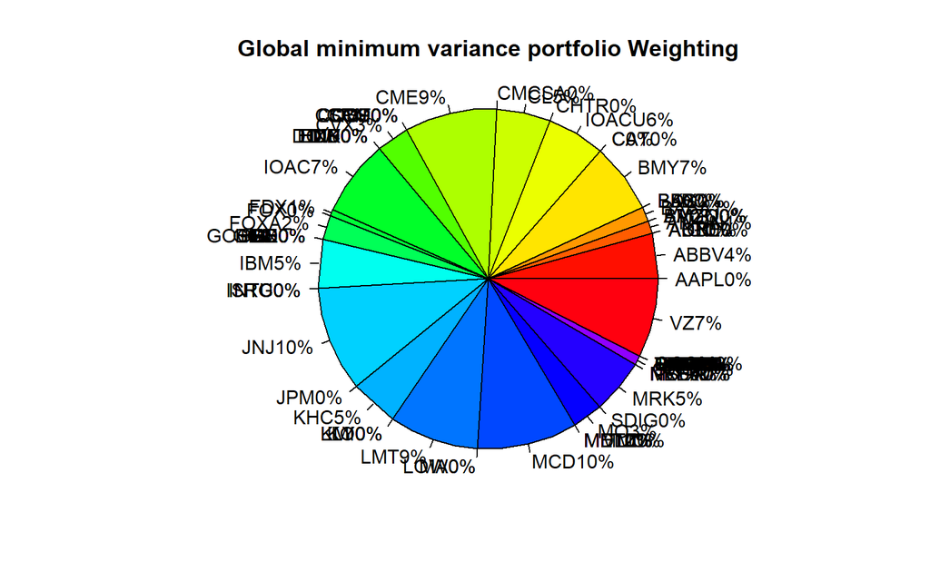

```r
pie.values<- as.numeric(weight_minvar)
pie.label<-colnames(weight_minvar)
pct<-round(pie.values*100)
pie.labels<-paste(pie.label,pct,"%",sep="") # Add Pct to Labels
pie(pie.values,labels=pie.labels,col=rainbow(length(pie.labels)),main="Global minimum variance portfolio Weighting", edges = 60 , radius = 1)
```

#### 2.1.3.2 Option 2: Choosing the efficient portfolio having the maximum Sharpe ratio

Sharpe ratio of a portfolio is
$$\frac{r_P-r_f}{\sigma_P}$$
, where $r_P$ is the expected mean portfolio return, $\sigma_P$ is the standard deviation of the portfolio return, $r_f$ is the risk-free interest rate.

Sharpe ratio of a portfolio measures the excess of portfolio return (over the risk-free interest rate) per one unit of risk (the standard deviation of portfolio return).

The higher the Sharpe ratio, the better the portfolio.

Tangency portfolio is the efficient portfolio having the maximum Sharpe ratio.

```r
# Suppose the risk-free interest rate is 7%
riskfree <- 0.07

tgt.port$Sharpe<-(tgt.port$tgt.ret-riskfree)/tgt.port$tgt.sd
tangency.port1<-subset(tgt.port,tgt.port$Sharpe==max(tgt.port$Sharpe))

par(mfrow=c(10,10))
tangency.port <- tangency.port1[, paste0("wgt.S", 1:100), drop = FALSE]
colnames(tangency.port) <-paste0("S", 1:100)
```

```r
tangency.port <- tangency.port[1, ]
# Normalize weights to sum to 1
tangency.port <- pmax(tangency.port, 0)
tangency.port <- tangency.port / sum(tangency.port)
tangency.port
```

```
##              S1 S2 S3           S4          S5 S6 S7 S8         S9          S10
## 96 1.764696e-16  0  0 5.848695e-17 1.44953e-17  0  0  0 0.06961962 9.261018e-17
##    S11          S12 S13          S14 S15 S16 S17          S18          S19 S20
## 96   0 3.095094e-16   0 7.216408e-17   0   0   0 4.579905e-17 7.075784e-18   0
##    S21          S22 S23 S24 S25 S26 S27 S28          S29          S30
## 96   0 1.028108e-17   0   0   0   0   0   0 7.719759e-17 1.367691e-16
##             S31          S32 S33         S34          S35          S36
## 96 2.474241e-16 3.456325e-16   0 2.83031e-16 3.996743e-17 1.061806e-17
##             S37          S38 S39          S40          S41        S42 S43
## 96 6.694294e-18 1.840896e-17   0 5.741703e-16 1.128989e-17 0.08749663   0
##             S44 S45 S46          S47 S48 S49          S50 S51        S52
## 96 1.974877e-16   0   0 6.056768e-16   0   0 2.241658e-17   0 4.5535e-17
##             S53          S54          S55          S56 S57 S58       S59
## 96 4.795115e-17 4.206122e-16 1.969978e-16 4.032523e-17   0   0 0.7401381
##             S60          S61 S62         S63          S64 S65          S66
## 96 1.420033e-18 2.401728e-16   0 1.61704e-16 1.771526e-17   0 1.887541e-16
##             S67          S68 S69        S70 S71          S72 S73 S74 S75
## 96 1.429358e-16 6.753388e-17   0 0.04533172   0 9.514379e-17   0   0   0
##             S76 S77        S78          S79 S80 S81          S82 S83
## 96 4.074986e-17   0 0.05741393 8.102479e-16   0   0 2.627175e-16   0
##             S84 S85          S86 S87 S88         S89 S90          S91
## 96 1.838982e-17   0 2.078039e-16   0   0 1.28394e-16   0 8.910413e-17
##             S92 S93          S94          S95         S96          S97
## 96 8.499448e-17   0 4.623105e-16 1.822857e-16 6.57138e-17 2.798837e-17
##             S98          S99 S100
## 96 1.457644e-16 3.245928e-17    0
```

[figure not shown]

```r
pie.values<- as.numeric(tangency.port)
pie.label<-colnames(tangency.port)
pct<-round(pie.values*100)
pie.labels<-paste(pie.label,pct,"%",sep="") # Add Pct to Labels

pie(pie.values,labels=pie.labels,col=rainbow(length(pie.labels)),main="Global minimum variance portfolio Weighting", edges = 60 , radius = 1)
```

**comment**: When choosing the efficient portfolio having the maximum Sharpe ratio or the minimum variance, we have the different results.

#### 2.1.3.3 Visualization of Efficient portfolios

```r
# Identify Efficient Portfolios
eff.frontier<-subset(tgt.port,tgt.port$tgt.ret>=minvar.port$tgt.ret)
head(eff.frontier)
```

```
##         tgt.ret      tgt.sd       wgt.S1     wgt.S2       wgt.S3       wgt.S4
## 67 0.0002130625 0.007021115 2.545289e-17 0.04309301 6.683105e-17 8.093105e-17
## 68 0.0136614063 0.007027867 2.825179e-17 0.04621127 6.505287e-17 7.968947e-17
## 69 0.0271097501 0.007052215 3.138646e-17 0.04907987 6.376061e-17 7.855788e-17
## 70 0.0405580939 0.007090875 3.662563e-17 0.05037382 6.551529e-17 7.814002e-17
## 71 0.0540064377 0.007141228 4.151769e-17 0.05113599 6.687279e-17 7.955451e-17
## 72 0.0674547815 0.007202524 4.640975e-17 0.05189816 6.823029e-17 8.096901e-17
##          wgt.S5        wgt.S6     wgt.S7        wgt.S8       wgt.S9
## 67 1.250175e-17  1.270257e-17 0.01220971 -1.446897e-17 1.719748e-17
## 68 1.580080e-17  8.585428e-18 0.02340331 -1.365244e-17 1.456344e-17
## 69 1.855824e-17  4.550425e-18 0.03386178 -1.247262e-17 1.212760e-17
## 70 1.792219e-17  1.045388e-18 0.03969270 -9.019609e-18 1.093264e-17
## 71 1.793788e-17 -1.333984e-18 0.04468268  4.373890e-20 9.433559e-18
## 72 1.125828e-17 -3.713355e-18 0.04967267  3.130119e-17 1.201215e-18
##         wgt.S10     wgt.S11       wgt.S12      wgt.S13       wgt.S14
```

[output cut: 125 more lines]

[figure not shown]

```r
plot(x=tgt.sd,
     xlab="Portfolio Risk",
     y=tgt.ret,
     ylab="Portfolio Return",
     col="blue",
     main="Mean-Variance Efficient Frontier of Two Assets
     Based on the Quadratic Programming Approach")
abline(h=0,lty=1)
points(x=minvar.port$tgt.sd,y=minvar.port$tgt.ret,pch=17,cex=3,col="red")
points(x=tangency.port1$tgt.sd,y=tangency.port1$tgt.ret,pch=19,cex=3,col="purple")
points(x=eff.frontier$tgt.sd,y=eff.frontier$tgt.ret,col="green")
```

```r
minvar.port$tgt.sd
```

```
## [1] 0.007021115
```

```r
minvar.port$tgt.ret
```

```
## [1] 0.0002130625
```

```r
tangency.port1$tgt.sd
```

```
## [1] 0.01450943
```

```r
tangency.port1$tgt.ret
```

```
## [1] 0.390215
```

## 2.2 Method 2: Building a neutral network model

**Meaning of symbols:**

$l = 1, 2, 3, ..., N$: Layer

$N$: Number of layers

$n_l$: The number of nodes contained in layer l.

$w_{i,j}^{l,l+1}$: Weight of the connection betwween node $j$ of layer $l$ to node $i$ of layer $l+1$

$i=1,2,3,..., n_{l+1}$ and $j=0, 1, 2,..., n_l$.

**Generalizations form:**

$z_i^{l+1}=\sum_{j=0}^{n_l} w_{i,j}^{l,l+1}a_j^l$

$a_i^l = f(z_i^{l+1})$: The activation function form

**Idea:**

I have two ideas to create a neural network for minimum risk or maximum return, and they are depicted through the diagrams I drew below.

Idea 1:

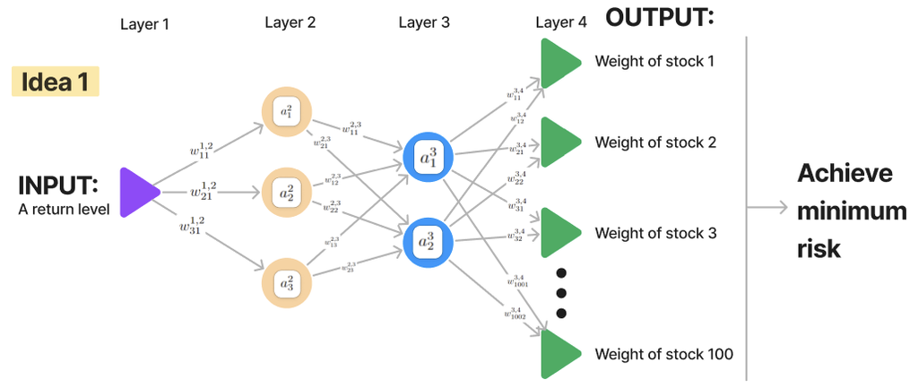

Idea 2:

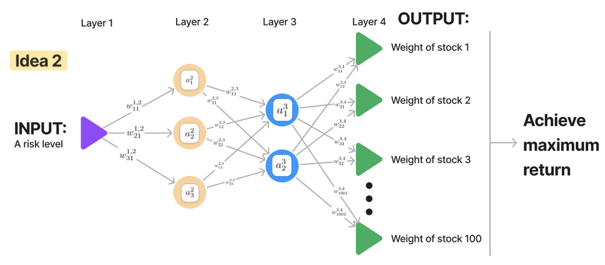

Nguyen Phan Khanh Linh